# Vectors, Matricies, and Operations

[Computational Mathematics and Statistics Camp](https://github.com/math-camp/course) University of Chicago September 2018

## Linear algebra

- Data stored in **matricies**
- Higher dimensional spaces
  - Flood of big data, stored in many dimensions
- Linear algebra
  - Algebra of matricies
  - Geometry of high dimensional space
  - Calculus (multivariable) in many dimensions
- Very important for regression/machine learning/deep learning

## Points and vectors

- A point in $\Re^1$
  - $1$
  - $\pi$
  - $e$
- An ordered pair in $\Re^2 = \Re \times \Re$
  - $(1,2)$
  - $(0,0)$
  - $(\pi, e)$
- An ordered triple in $\Re^3 = \Re \times \Re \times \Re$
  - $(3.1, 4.5, 6.1132)$
- An ordered $n$-tuple in $R^n = \Re \times \Re \times \ldots \times \Re$
  - $(a_{1}, a_{2}, \ldots, a_{n})$

## Points and vectors

> A point $\mathbf{x} \in \Re^{n}$ is an ordered n-tuple, $(x_{1}, x_{2}, \ldots, x_{n})$. The vector $\mathbf{x} \in \Re^{n}$ is the arrow pointing from the origin $(0, 0, \ldots, 0)$ to $\mathbf{x}$.

## One dimensional example

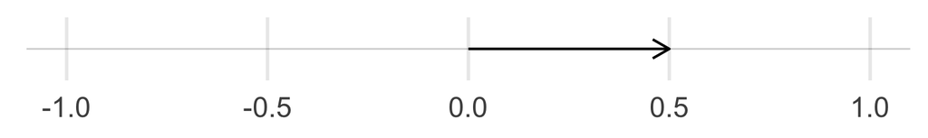

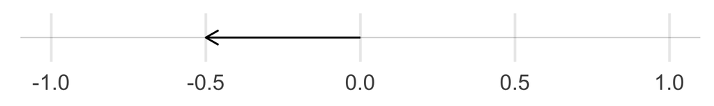

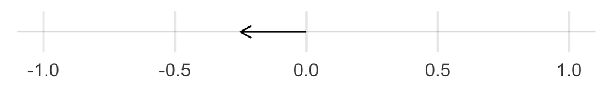

## Two dimensional example

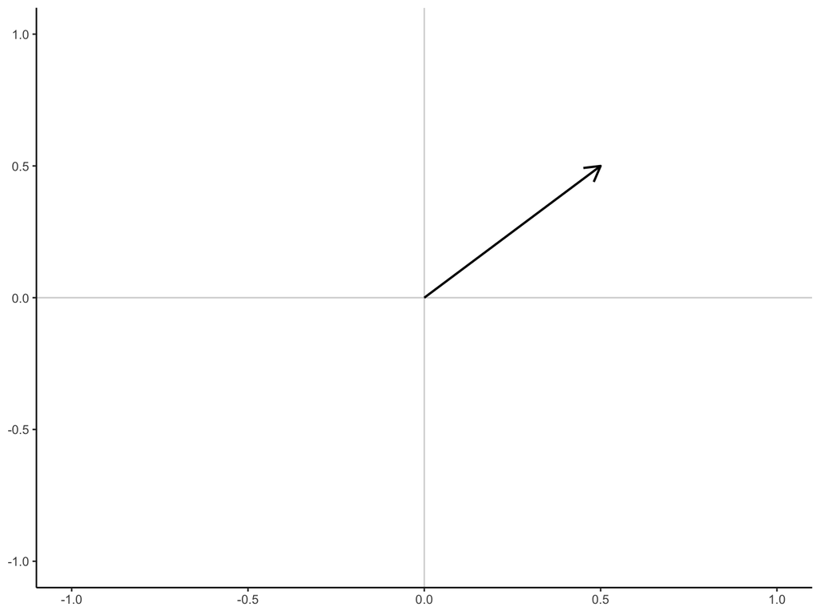

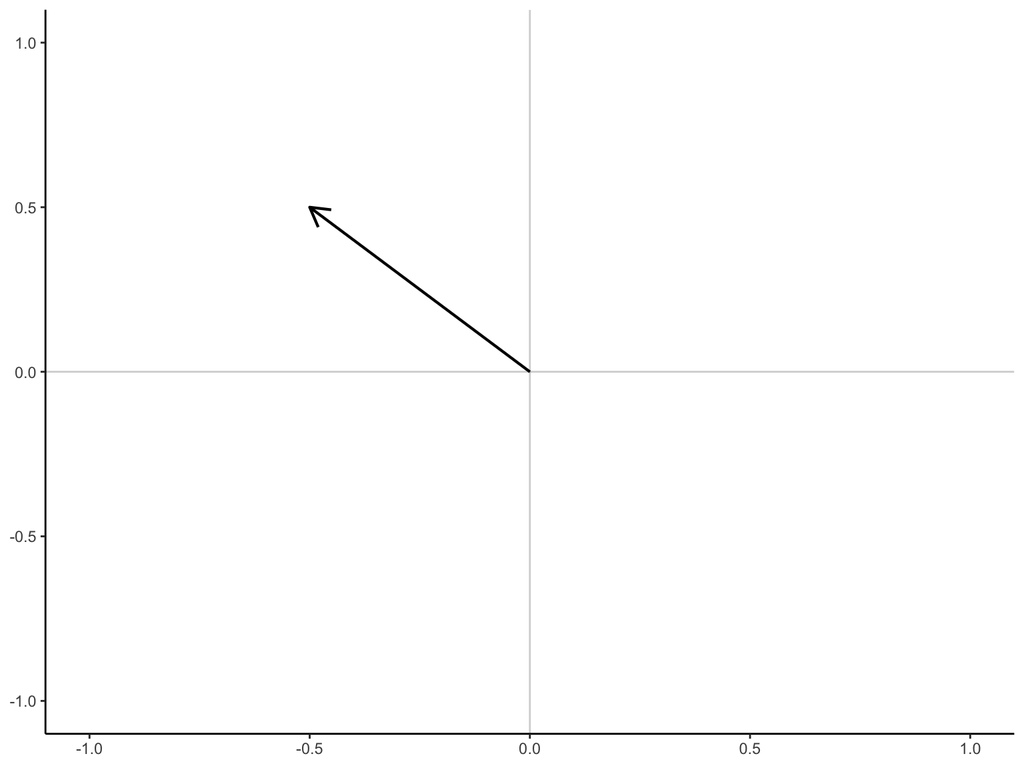

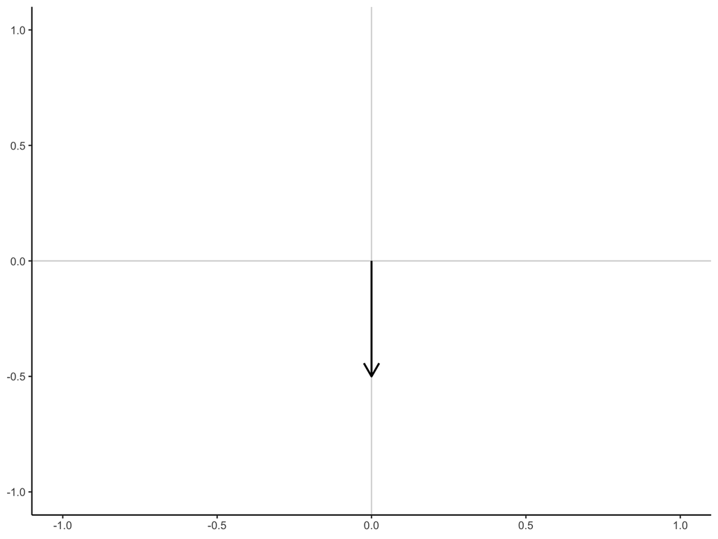

## Three dimensional example

- (Latitude, Longitude, Elevation)
- $(1,2,3)$
- $(0,1,2)$

## $N$-dimensional example

- Individual campaign donation records
  $$\mathbf{x} = (1000, 0, 10, 50, 15, 4, 0, 0, 0, \ldots, 2400000000)$$
- Counties have proportion of vote for Trump
  $$\mathbf{y} = (0.8, 0.5, 0.6, \ldots, 0.2)$$
- Run experiment, assess feeling thermometer of elected official
  $$\mathbf{t} = (0, 100, 50, 70, 80, \ldots, 100)$$

## Vector arithmetic

Suppose:

$$\begin{aligned}
\mathbf{u} & = (1, 2, 3, 4, 5) \nonumber \\
\mathbf{v} & = (1, 1, 1, 1, 1) \nonumber \\
k & = 2
\end{aligned}$$

Then,

$$\begin{aligned}
\mathbf{u} + \mathbf{v} & = (1 + 1, 2 + 1, 3+ 1, 4 + 1, 5+ 1) = (2, 3, 4, 5, 6)\nonumber \\
k \mathbf{u} & = (2 \times 1, 2 \times 2, 2 \times 3, 2 \times 4, 2 \times 5) = (2, 4, 6, 8, 10) \nonumber \\
k \mathbf{v} & = (2 \times 1,2 \times 1,2 \times 1,2 \times 1,2 \times 1) = (2, 2, 2, 2, 2)
\end{aligned}$$

## Inner product

$$\begin{aligned}
\mathbf{u} \cdot \mathbf{v} &= u_{1} v_{1} + u_{2}v_{2} + \ldots + u_{n} v_{n} \nonumber \\
& = \sum_{i=1}^{N} u_{i} v_{i} \nonumber
\end{aligned}$$

## Inner product

Suppose $\mathbf{u} = (1, 2, 3)$ and $\mathbf{v} = (2, 3, 1)$. Then:

$$\begin{aligned}
\mathbf{u} \cdot \mathbf{v} & = 1 \times 2 + 2 \times 3 + 3 \times 1 \\
& = 2+ 6 + 3 \\
& = 11
\end{aligned}$$

## Calculating vector length

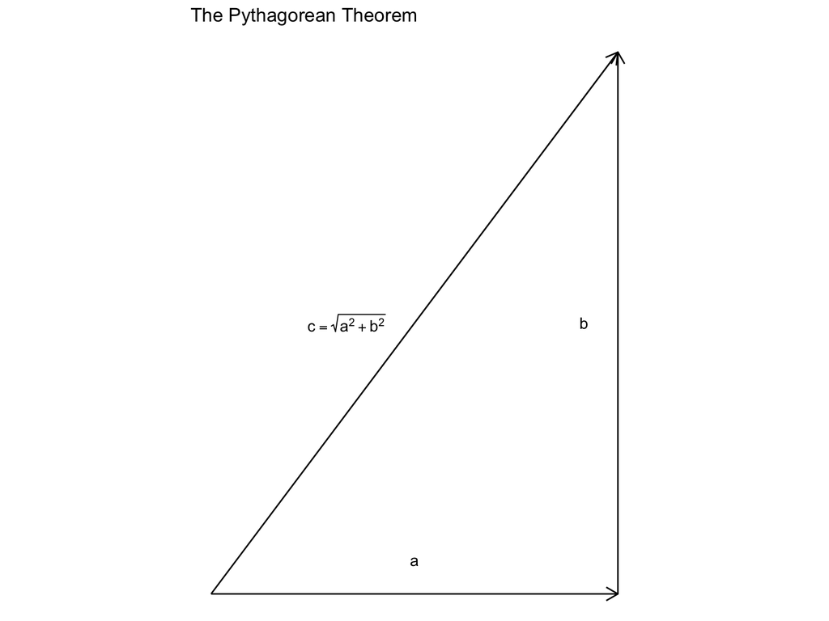

## Vector norm

$$\begin{aligned}
\| \mathbf{v}\| & = (\mathbf{v} \cdot \mathbf{v} )^{1/2} \\
& = (v_{1}^2 + v_{2}^{2} + v_{3}^{2} + \ldots + v_{n}^{2} )^{1/2}
\end{aligned}$$

- Vector norm of a three-dimensional vector $\mathbf{x} = (1,1,1)$

  $$\begin{aligned}
  \| \mathbf{x}\| & = (\mathbf{x} \cdot \mathbf{x} )^{1/2} \\
  & = (x_{1}^2 + x_{2}^{2} + x_{3}^{2})^{1/2} \\
  & = (1 + 1 + 1)^{1/2} \\
  &= \sqrt{3}
  \end{aligned}$$

## Example: text analysis

```
 a abandoned abc ability able about above abroad absorbed absorbing abstract
43         0   0       0    0    10     0      0        0         0        1
```

- $(43,0,0,0,0,10,\dots)$

## Example: text analysis

$$\begin{aligned}
\text{Doc1} & = (1, 1, 3, \ldots, 5) \\
\text{Doc2} & = (2, 0, 0, \ldots, 1) \\
\textbf{Doc1}, \textbf{Doc2} & \in \Re^{M}
\end{aligned}$$

## Inner product

$$\begin{aligned}
\textbf{Doc1} \cdot \textbf{Doc2} & = (1, 1, 3, \ldots, 5) (2, 0, 0, \ldots, 1)' \\
& = 1 \times 2 + 1 \times 0 + 3 \times 0 + \ldots + 5 \times 1 \\
& = 7
\end{aligned}$$

## Length

$$\begin{aligned}
\| \textbf{Doc1} \| & \equiv \sqrt{ \textbf{Doc1} \cdot \textbf{Doc1} } \\
& = \sqrt{(1, 1, 3, \ldots , 5) (1, 1, 3, \ldots, 5)' } \\
& = \sqrt{1^{2} +1^{2} + 3^{2} + 5^{2} } \\
& = 6
\end{aligned}$$

## Cosine

$$\begin{aligned}
\cos (\theta) & \equiv \left(\frac{\textbf{Doc1} \cdot \textbf{Doc2}}{\| \textbf{Doc1}\| \|\textbf{Doc2} \|} \right) \\
& = \frac{7} { 6 \times 2.24} \\
& = 0.52
\end{aligned}$$

## Measuring similarity

- Why it is useful
- What properties show a similarity measure have?
  - The **maximum** should be the document with itself
  - The **minimum** should be documents which have no words in common (i.e. **orthogonal**)
  - Increasing when more of the same words are used
  - Normalize for document length

## Measure 1: inner product

$$(2,1) \cdot (1,4) = 6$$

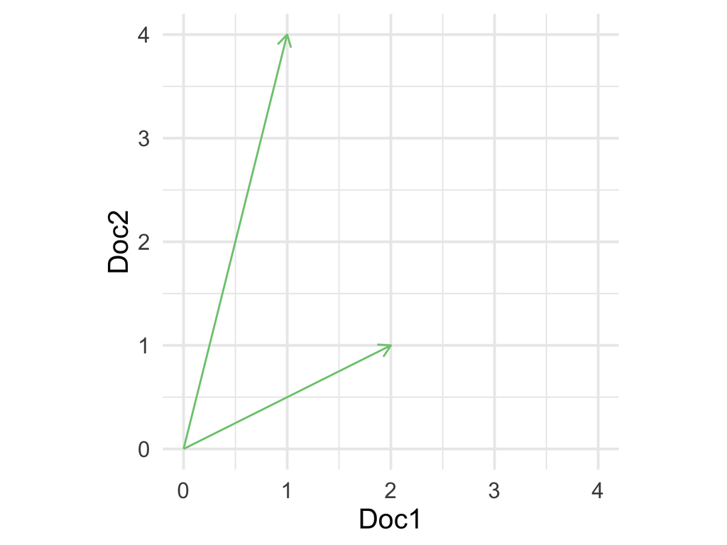

## Measure 1: inner product

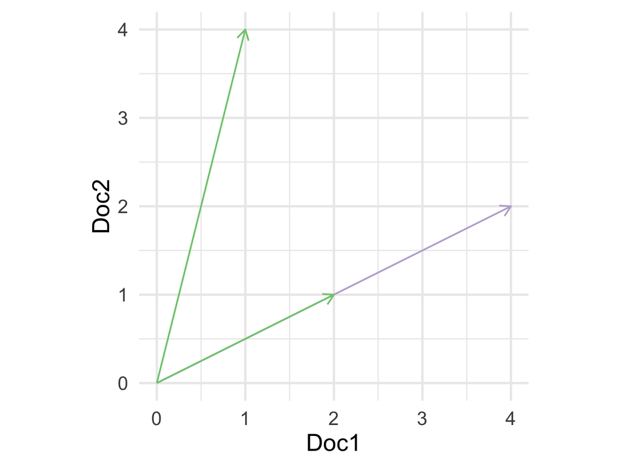

$$(4,2) \cdot (1,4) = 12$$

## Measure 2: cosine similarity

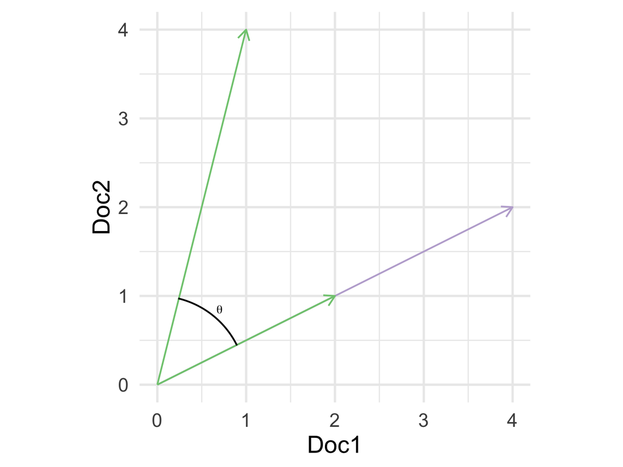

$$\begin{aligned}
(4,2) \cdot (1,4) &= 12 \\
\mathbf{a} \cdot \mathbf{b} &= \|\mathbf{a} \| \times \|\mathbf{b} \| \times \cos(\theta)
\end{aligned}$$

## Measure 2: cosine similarity

$$\begin{aligned}
\cos (\theta) & \equiv \left(\frac{\textbf{Doc1} \cdot \textbf{Doc2}}{\| \textbf{Doc1}\| \|\textbf{Doc2} \|} \right) \\
& = \frac{(2, 1) \cdot (1, 4)} {\| (2,1)\| \| (1,4) \|} \\
& = \frac{6} {(\sqrt{2^2 + 1^2}) (\sqrt{1^2 + 4^2})} \\
& = \frac{6} {(\sqrt{5}) (\sqrt{17})} \\
& \approx 0.65
\end{aligned}$$

$$\begin{aligned}
\cos (\theta) & \equiv \left(\frac{\textbf{Doc3} \cdot \textbf{Doc2}}{\| \textbf{Doc3}\| \|\textbf{Doc2} \|} \right) \\
& = \frac{(4,2) \cdot (1, 4)} {\| (24,2)\| \| (1,4) \|} \\
& = \frac{12} {(\sqrt{4^2 + 2^2}) (\sqrt{1^2 + 4^2})} \\
& = \frac{12} {(\sqrt{20}) (\sqrt{17})} \\
& \approx 0.65
\end{aligned}$$

## Matricies

- Rectangular arrangement (array) of numbers defined by two **axes**
  1. Rows
  2. Columns

     $$\mathbf{A} =
     \begin{array}{rrrr}
     a_{11} & a_{12} & \ldots & a_{1n} \\
     a_{21} & a_{22} & \ldots & a_{2n} \\
     \vdots & \vdots & \ddots & \vdots \\
     a_{m1} & a_{m2} & \ldots & a_{mn} \\
     \end{array}$$

     If $\mathbf{A}$ has $m$ rows $n$ columns we will say that $\mathbf{A}$ is an $m \times n$ matrix. Suppose $\mathbf{X}$ and $\mathbf{Y}$ are $m \times n$ matrices. Then $\mathbf{X} = \mathbf{Y}$ if $x_{ij} = y_{ij}$ for all $i$ and $j$.

## Simple examples

$$\mathbf{X} = \left[ \begin{array}{rrr}
1 & 2 & 3 \\
2 & 1 & 4 \\
\end{array} \right]$$

$$\mathbf{Y} = \left[ \begin{array}{rr}
1 & 2 \\
3 & 2 \\
1 & 4 \\
\end{array} \right]$$

## Matrix addition

Suppose $\mathbf{X}$ and $\mathbf{Y}$ are $m \times n$ matrices. Then:

$$\begin{aligned}
\mathbf{X} + \mathbf{Y} & = \begin{pmatrix}
x_{11} & x_{12} & \ldots & x_{1n} \\
x_{21} & x_{22} & \ldots & x_{2n} \\
\vdots & \vdots & \ddots & \vdots \\
x_{m1} & x_{m2} & \ldots & x_{mn} \\
\end{pmatrix} +
\begin{pmatrix}
y_{11} & y_{12} & \ldots & y_{1n} \\
y_{21} & y_{22} & \ldots & y_{2n} \\
\vdots & \vdots & \ddots & \vdots \\
y_{m1} & y_{m2} & \ldots & y_{mn} \\
\end{pmatrix}
\nonumber \\
& = \begin{pmatrix}
x_{11} + y_{11} & x_{12} + y_{12} & \ldots & x_{1n} + y_{1n} \\
x_{21} + y_{21} & x_{22} + y_{22} & \ldots & x_{2n} + y_{2n} \\
\vdots & \vdots & \ddots & \vdots\\
x_{m1} + y_{m1} & x_{m2} + y_{m2} & \ldots & x_{mn} + y_{mn} \\
\end{pmatrix}
\end{aligned}$$

Suppose $\mathbf{X}$ is an $m \times n$ matrix and $k \in \Re$. Then:

$$\begin{aligned}
k \mathbf{X} & = \begin{pmatrix}
k x_{11} & k x_{12} & \ldots & k x_{1n} \\
k x_{21} & k x_{22} & \ldots & k x_{2n} \\
\vdots & \vdots & \ddots & \vdots \\
k x_{m1} & k x_{m2} & \ldots & k x_{mn} \\
\end{pmatrix}
\end{aligned}$$

## Transposition

$$\begin{aligned}
\mathbf{X} & = \begin{pmatrix}
x_{11} & x_{12} & \ldots & x_{1n} \\
x_{21} & x_{22} & \ldots & x_{2n} \\
\vdots & \vdots & \ddots & \vdots \\
x_{m1} & x_{m2} & \ldots & x_{mn} \\
\end{pmatrix} \\
\mathbf{X}' & = \begin{pmatrix}
x_{11} & x_{21} & \ldots & x_{m1} \\
x_{12} & x_{22} & \ldots & x_{m2} \\
\vdots & \vdots & \ddots & \vdots \\
x_{1n} & x_{2n} & \ldots & x_{mn}
\end{pmatrix}
\end{aligned}$$

- If $\mathbf{X}$ is an $m \times n$ then $\mathbf{X}'$ is $n \times m$
- If $\mathbf{X} = \mathbf{X}'$ then we say $\mathbf{X}$ is symmetric

  $$\mathbf{X} = \begin{pmatrix} 4 & 1 & 2 \\1 & 2 & 3 \\ \end{pmatrix} \quad \mathbf{X}^{'} = \begin{pmatrix} 4 & 1 \\ 1 & 2 \\ 2 & 3 \\ \end{pmatrix}$$

## Matrix multiplication

$$\mathbf{X} = \begin{pmatrix} 1 & 1 \\ 1& 1 \\ \end{pmatrix} , \quad \mathbf{Y} = \begin{pmatrix} 1 & 2 \\ 3 & 4 \\ \end{pmatrix}$$

Create a new matrix $\mathbf{A}$ by matrix multiplication:

$$\begin{aligned}
\mathbf{A} & = \mathbf{X} \mathbf{Y} \\
& = \begin{pmatrix}
1 & 1 \\
1 & 1 \\
\end{pmatrix}
\begin{pmatrix}
1 & 2 \\
3 & 4 \\
\end{pmatrix} \\
&= \begin{pmatrix}
1 \times 1 + 1 \times 3 & 1 \times 2 + 1 \times 4 \\
1 \times 1 + 1 \times 3 & 1 \times 2 + 1 \times 4\\
\end{pmatrix} \\
&= \begin{pmatrix}
4 & 6 \\
4 & 6
\end{pmatrix}
\end{aligned}$$

## Algebraic properties

- Matricies must be **conformable**
- Associative property: $(\mathbf{XY})\mathbf{Z} = \mathbf{X}(\mathbf{YZ})$
- Additive distributive property: $(\mathbf{X} + \mathbf{Y})\mathbf{Z} = \mathbf{XZ} + \mathbf{YZ}$
- Zero property: $\mathbf{X0} = 0$
- Order matters: $\mathbf{XY} \neq \mathbf{YX}$
  - Different from scalar multiplication: $xy = yx$

## What is deep learning?

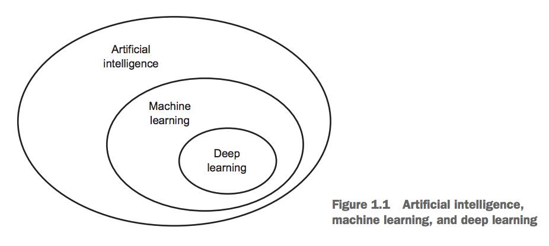

## Learning representations from data

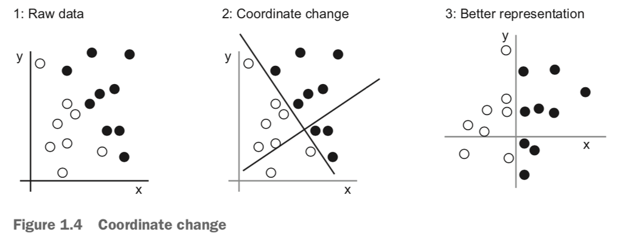

## The “deep” in deep learning

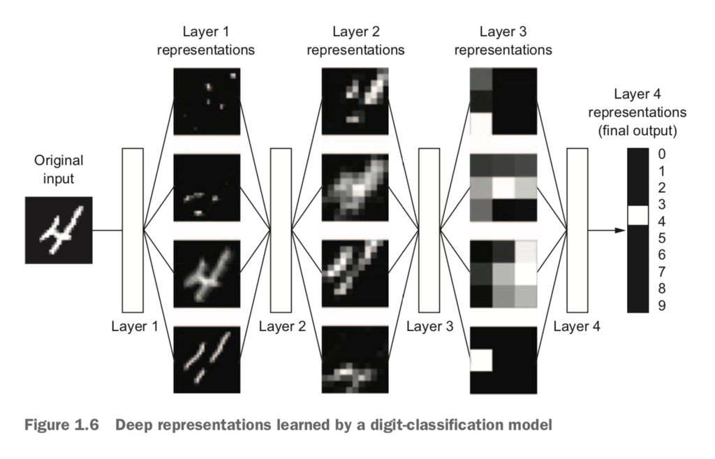

## How is deep learning used

- Self-driving cars
- Voice activated assistants
- Automatic machine translation
- Image recognition
- Detection of diseases

## How is deep learning related to linear algebra?

- Tensor
- Scalars (0D tensors)
- Vectors (1D tensors)
- Matricies (2D tensors)
- 3D tensors and higher-dimensional tensors

## Tensor operations

- Generalizations of matrix operations
- Add tensors
- Multiple tensors
- If you can do it with a matrix, you can do it with a tensor

## Geometric interpretation

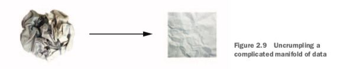

## Here is the linear algebra

$$\text{output} = \text{relu}([W \cdot \text{input}] + b)$$

- `input` - the input data
- `dot()` - dot product (tensor multiplication)
- `relu()` - element-wise operations
  - Operations applied independently to each entry (cell/value) in the tensor
  - Highly scalable
- $W, b$ - tensors that are attributes of the layer
  - Weights
  - Parameters